# Index

Palma Luna Melissa

2025-02-02

# Differential expression analysis of the recount3 project: **SRP124965**

A Differential expression analysis was conducted on the study **“Epigenome-wide Effects of Vitamin-D on Bronchial Epithelial Cells using ATAC-Seq and RNA-seq”**, obtained from the [Recount3 Study Explorer](https://jhubiostatistics.shinyapps.io/recount3-study-explorer/), to assess the effect of Vitamin D3 (also refereed as calcitriol) across different cell lines of human bronchial epithelial cells, utilizing various [Bioconductor](https://bioconductor.org) tools.

**Project description in the Recount3:** Vitamin D has been associated with viral respiratory infections, the main cause of severe asthma exacerbations in children. We used ATAC-Seq to evaluate the effect of vitamin D on chromatin accessibility in immortalized (BEAS-2B), normal (NHBEC), and asthma (AAEC) bronchial epithelial cells cultured and stimulated with calcitriol, poly I:C (to simulate viral infection), both, or sham (culture media), as well as the effect on gene expression. Overall design: ATAC-Seq and total RNA-Seq were performed on 4 asthma human bronchial epithelial cell samples (AAEC), 4 normal human bronchial epithelial cell samples (NHBEC) and 4 immortalized (BEAS-2B) samples, respectively treated with calcitriol, poly I:C, both or sham (culture media).

**Overview of the different treatments and cell lines for the experiment:**

Cell lines:

- Normal human bronchial epithelial
- Asthma human bronchial epithelial
- BEAS-2B immortalized human bronchial epithelial

Treatments:

- Vitamin D3 or calcitriol
- Poly (I:C)
- calcitriol + Poly (I:C)
- Sham (cultured media)

# Reduced Protocol

## Previous Steps

The fist part of the analysis consisted in the preparation of a [RangedSummarizedExperiment](https://www.bioconductor.org/packages/devel/bioc/vignettes/SummarizedExperiment/inst/doc/SummarizedExperiment.html) (RSE) object. The code for this step can be found in the R script named: `main_script.R`, for which fragments will be pasted below with additional comments relevant to the analysis:

### Load Packages

```r
## ---------------------------------
##            Path
## ---------------------------------
setwd("~/Desktop/Bioconductor_Final_project")
## ---------------------------------
##           R_packages
## ---------------------------------
library("recount3")
library("edgeR")
library("limma")
library("ggplot2")
library("pheatmap")
library("ExploreModelMatrix")
```

### RSE object creation

```r
## ---------------------------------
##         Data_Download
## ---------------------------------
# Download list of all human experiments
human_projects <- available_projects()

## Create a RangedSummarizedExperiment (RSE) object using the ID
## of the choosen project
project_vit_D <- create_rse(subset(human_projects,
  project == "SRP124965" & project_type == "data_sources"
))
```

### Explore and Modify the RSE object

```r
## ----------------------------------------
##             Explore_object
## ----------------------------------------

project_vit_D
```

```
## class: RangedSummarizedExperiment
## dim: 63856 12
## metadata(8): time_created recount3_version ... annotation recount3_url
## assays(1): raw_counts
## rownames(63856): ENSG00000278704.1 ENSG00000277400.1 ...
##   ENSG00000182484.15_PAR_Y ENSG00000227159.8_PAR_Y
## rowData names(10): source type ... havana_gene tag
## colnames(12): SRR6290091 SRR6290083 ... SRR6290093 SRR6290094
## colData names(175): rail_id external_id ...
##   recount_pred.curated.cell_line BigWigURL
```

The previous results revealed that converting the provided counts from base-pair count to read count is a necessary step.

```r
## ------Change_to_read_counts------
assay(project_vit_D, "counts") <- compute_read_counts(project_vit_D)

##-------Facilitate Metadata access------
# project_vit_D$sra.sample_attributes[1:12] # inspect attributes
expand_sra_attributes(project_vit_D) ## No problems with the Data
```

```
## class: RangedSummarizedExperiment
## dim: 63856 12
## metadata(8): time_created recount3_version ... annotation recount3_url
## assays(2): raw_counts counts
## rownames(63856): ENSG00000278704.1 ENSG00000277400.1 ...
##   ENSG00000182484.15_PAR_Y ENSG00000227159.8_PAR_Y
## rowData names(10): source type ... havana_gene tag
## colnames(12): SRR6290091 SRR6290083 ... SRR6290093 SRR6290094
## colData names(178): rail_id external_id ... sra_attribute.source_name
##   sra_attribute.treatment
```

```r
## The metadata in the single the SRA (Sequence Read Archive) column is
## separated into several ones in colData
project_vit_D <- expand_sra_attributes(project_vit_D)

## Showcases resultant columns
colData(project_vit_D)[
  ,
  grepl("^sra_attribute", colnames(colData(project_vit_D)))
]
```

```
## DataFrame with 12 rows and 3 columns
##            sra_attribute.cell_type sra_attribute.source_name
##                        <character>               <character>
## SRR6290091  Normal human bronchi..    Normal human bronchi..
## SRR6290083  Asthma human bronchi..    Asthma human bronchi..
## SRR6290084  Asthma human bronchi..    Asthma human bronchi..
## SRR6290085  Asthma human bronchi..    Asthma human bronchi..
## SRR6290086  Asthma human bronchi..    Asthma human bronchi..
## ...                            ...                       ...
## SRR6290089  BEAS-2B immortalized..                   BEAS-2B
## SRR6290090  BEAS-2B immortalized..                   BEAS-2B
## SRR6290092  Normal human bronchi..    Normal human bronchi..
## SRR6290093  Normal human bronchi..    Normal human bronchi..
## SRR6290094  Normal human bronchi..    Normal human bronchi..
##            sra_attribute.treatment
##                        <character>
## SRR6290091              Calcitriol
## SRR6290083              Calcitriol
## SRR6290084   Calcitriol + Poly I:C
## SRR6290085                Poly I:C
## SRR6290086    Sham (culture media)
## ...                            ...
## SRR6290089                Poly I:C
## SRR6290090    Sham (culture media)
## SRR6290092   Calcitriol + Poly I:C
## SRR6290093                Poly I:C
## SRR6290094    Sham (culture media)
```

For the `sra_attribute columns` of interest, a change of type is needed, as they are categorical variables. Additionally a calculation is needed to determine the assigned gene proportion.

```r
## Change character to factor
project_vit_D$sra_attribute.cell_type <- factor(project_vit_D$sra_attribute.cell_type)
project_vit_D$sra_attribute.treatment <- factor(project_vit_D$sra_attribute.treatment)
project_vit_D$sra_attribute.source_name <- factor(project_vit_D$sra_attribute.source_name)

## Proportion of lectures assigned to genes
project_vit_D$assigned_gene_prop<-project_vit_D$recount_qc.gene_fc_count_all.assigned / project_vit_D$recount_qc.gene_fc_count_all.total
summary(project_vit_D$assigned_gene_prop)
```

```
##    Min. 1st Qu.  Median    Mean 3rd Qu.    Max.
##  0.3072  0.4155  0.5175  0.4891  0.5697  0.6430
```

```r
## Note: The best sample has around 0.6430 of lectures assigned and 75% of the samples have less than 0.5697 assigned

## save data
unfiltered_vitamin_D<-project_vit_D
```

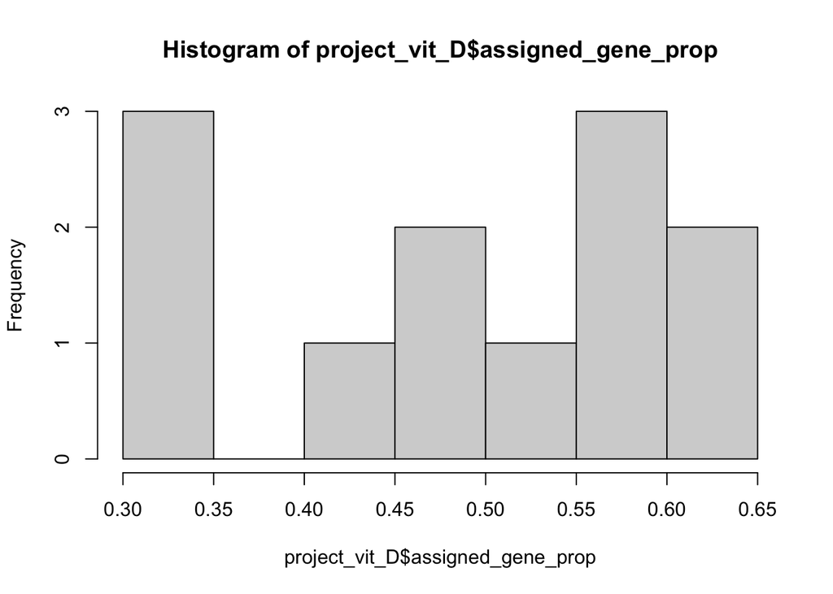

```r
##-------------------------------------------
##                  Filtering
##-------------------------------------------
hist(project_vit_D$assigned_gene_prop)
```

```r
## In this step two options were plausible: Don't Filter samples and Filtering those below the Mean
## further analysis on both can be found at the no_filter.R and Below_Mean.R scripts

## get the mean
summary(unfiltered_vitamin_D$assigned_gene_prop)
```

```
##    Min. 1st Qu.  Median    Mean 3rd Qu.    Max.
##  0.3072  0.4155  0.5175  0.4891  0.5697  0.6430
```

```r
## Create object for this alternative analysis
below_MEAN_project_vit_D<-project_vit_D
```

As shown before in the histogram, the values are mainly between 0.3 and 0.65, with no indications of obvious extreme or outliers. Therefore two options for the filtering process arise:

- Only delete those genes with an expression below the 0.1
- Filter those samples below the Mean and then delete those genes with an expression below 0.1

The code for the fist option its available at the script `no_filter.R` and for the second option at the script `Below_Mean.R`

Both scripts will be pasted below, with additional comments.

## Filtering

### Script 1: Don’t Filter samples and Delete genes with a low expression

```r
## ----------------------------------------
##        option 1: Don't Filter
## ----------------------------------------
## We are gonna continue with the Option: `Don't Filter samples`
## further analysis of the Option 2: `Filtering those below the Mean`
## is in the script Below_Mean.R

## Save the average expression of a gene in all samples
gene_means <- rowMeans(assay(project_vit_D, "counts"))
summary(gene_means)
```

```
##     Min.  1st Qu.   Median     Mean  3rd Qu.     Max.
##      0.0      0.0      0.4    366.3     38.3 512201.9
```

Filter genes with a low expression, get the percent of remaining genes after filtering and the number of samples left.

```r
## Delete genes with low mean expression
project_vit_D <- project_vit_D[gene_means > 0.1, ]

## Percent of remaining genes after filtering:
round(nrow(project_vit_D) / nrow(unfiltered_vitamin_D) * 100, 2)
```

```
## [1] 57.68
```

```r
# Number of samples:
dim(project_vit_D)
```

```
## [1] 36834    12
```

57.68 % of remaining genes and no samples deleted

### Script 2: Filter those samples below the Mean and Delete genes with a low expression

```r
## ----------------------------------------
## option 2: Filtering those below the Mean
## ----------------------------------------
## We are gonna continue with the Option: `Filtering those below the Mean`
## further analysis of the Option 1: `Filtering those below the Mean` is in the script no_filter.R
## Filter those below the mean (0.4891) using 0.4 instead of the complete number
below_MEAN_project_vit_D <- below_MEAN_project_vit_D[, below_MEAN_project_vit_D$assigned_gene_prop > 0.4]
## Save the average expression of a gene in all samples
gene_means_BM <- rowMeans(assay(below_MEAN_project_vit_D, "counts"))
```

Filter genes with a low expression, get the percent of remaining genes after filtering and the number of samples left.

```r
## Delete genes with low mean expression
below_MEAN_project_vit_D <- below_MEAN_project_vit_D[gene_means_BM > 0.1, ]
## Percent of remaining genes:
round(nrow(below_MEAN_project_vit_D) / nrow(unfiltered_vitamin_D) * 100, 2)
```

```
## [1] 61.45
```

```r
# Number of samples:
dim(below_MEAN_project_vit_D)
```

```
## [1] 39240     9
```

## Filtering and Normalization

After filtering we continue with the normalization step, again both options separated in the scripts mentioned before.

### 1. Script 1: Don’t Filter samples and Delete genes with a low expression

```r
## ----------------------------------------
##          Data Normalization
## ----------------------------------------
## edgeR object creation
dge<-DGEList(
  counts = assay(project_vit_D, "counts"),
  genes = rowData(project_vit_D)
)
## Normalization with the TMM method (default)
dge <- calcNormFactors(dge)
```

### 2. Script 2: Filter those samples below the Mean and Delete genes with a low expression

```r
## ----------------------------------------
##          Data Normalization
## ----------------------------------------
## edgeR object creation
dge_BM<-DGEList(
  counts = assay(below_MEAN_project_vit_D, "counts"),
  genes = rowData(below_MEAN_project_vit_D)
)
## Normalization with the TMM method (default)
dge_BM <- calcNormFactors(dge_BM)
```

#### Boxplots

The boxplots below helps us visualize the distibution between the our samples, treatments and gene proportion. Visually, we identify the samples that were deleted in the previous filtering step in the Option 2.

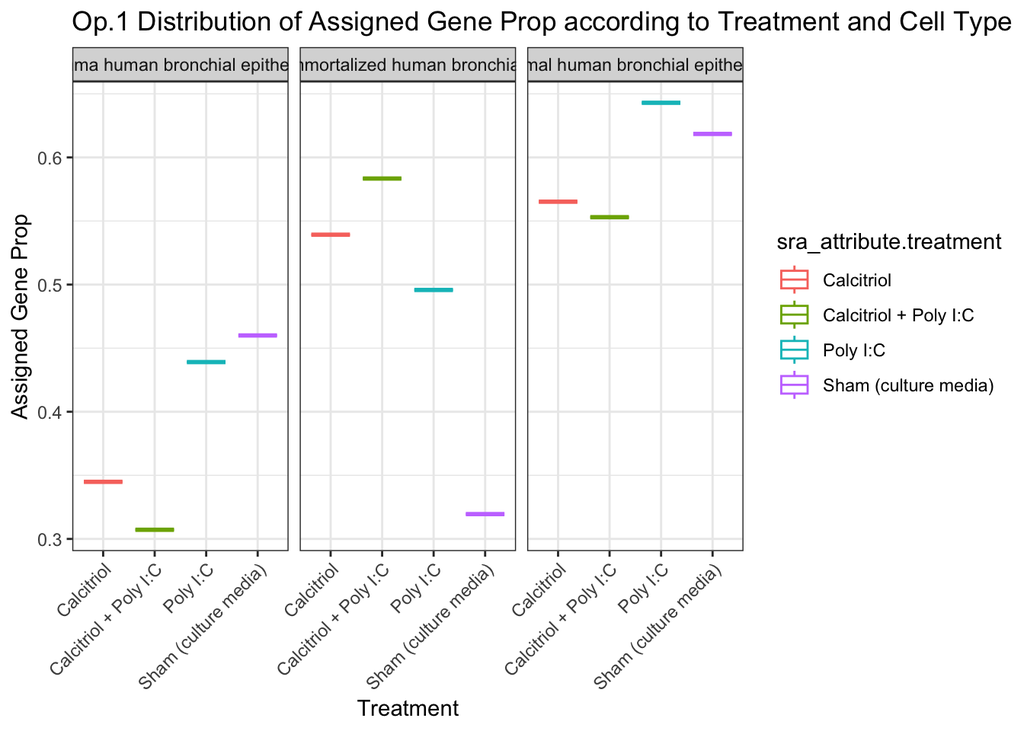

```r
## ----------------------------------------
##    Differential expression analysis
## ----------------------------------------
## ----------------------------
##            Graph
## ----------------------------
## -------------boxplot---------------
ggplot(as.data.frame(colData(project_vit_D)),
       aes(x = sra_attribute.treatment,y = assigned_gene_prop, color = sra_attribute.treatment)) +
  geom_boxplot() +
  facet_wrap(~ sra_attribute.cell_type) + # subgraph for each celltype
  theme_bw() +
  labs(title = "Op.1 Distribution of Assigned Gene Prop according to Treatment and Cell Type",
       x = "Treatment", y = "Assigned Gene Prop") +
  theme(axis.text.x = element_text(angle = 45, hjust = 1)) # labels and text
```

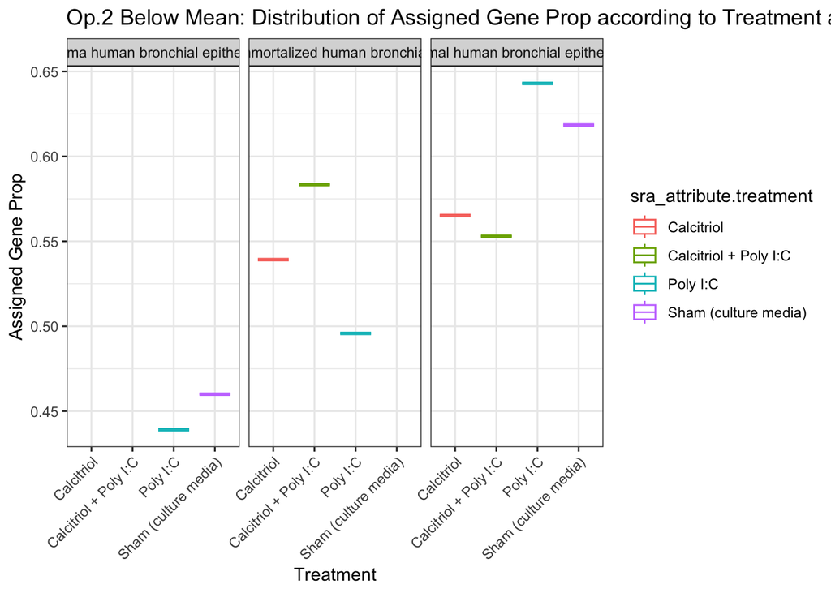

```r
## ----------------------------------------
##    Differential expression analysis
## ----------------------------------------
## ----------------------------
##            Graph
## ----------------------------
## -------------boxplot---------------
ggplot(as.data.frame(colData(below_MEAN_project_vit_D)),
       aes(x = sra_attribute.treatment,y = assigned_gene_prop, color = sra_attribute.treatment)) +
  geom_boxplot() +
  facet_wrap(~ sra_attribute.cell_type) + # subgraph for each celltype
  theme_bw() +
  labs(title = "Op.2 Below Mean: Distribution of Assigned Gene Prop according to Treatment and Cell Type",
       x = "Treatment", y = "Assigned Gene Prop") +
  theme(axis.text.x = element_text(angle = 45, hjust = 1)) # labels and text
```

## Differential expression analysis

The following design models how each treatment affects each cell type independently and whether there are specific effects of the combination of treatment and cell type, as stated in the objective of the analysis.

### 1. Script 1: Don’t Filter samples and Delete genes with a low expression

```r
## ----------------------------
## Creating the statistic model
## ----------------------------

## Model as a Function of the variables treatment, cell_type and assigned_gene_prop
models <- model.matrix(~ 0 + sra_attribute.cell_type + sra_attribute.treatment +
                         sra_attribute.cell_type:sra_attribute.treatment,
                    data = colData(project_vit_D)
                    )
```

### 2. Script 2: Filter those samples below the Mean and Delete genes with a low expression

```r
## ----------------------------
## Creating the statistic model
## ----------------------------
## Model as a Function of the variables treatment, cell_type and assigned_gene_prop
models_BM<- model.matrix (~ 0 + sra_attribute.cell_type + sra_attribute.treatment +
                         sra_attribute.cell_type:sra_attribute.treatment,
                           data = colData(below_MEAN_project_vit_D)
)
## names of the columns in the matrix
colnames(models_BM)
```

```
##  [1] "sra_attribute.cell_typeAsthma human bronchial epithelium"
##  [2] "sra_attribute.cell_typeBEAS-2B immortalized human bronchial epithelium"
##  [3] "sra_attribute.cell_typeNormal human bronchial epithelium"
##  [4] "sra_attribute.treatmentCalcitriol + Poly I:C"
##  [5] "sra_attribute.treatmentPoly I:C"
##  [6] "sra_attribute.treatmentSham (culture media)"
##  [7] "sra_attribute.cell_typeBEAS-2B immortalized human bronchial epithelium:sra_attribute.treatmentCalcitriol + Poly I:C"
##  [8] "sra_attribute.cell_typeNormal human bronchial epithelium:sra_attribute.treatmentCalcitriol + Poly I:C"
##  [9] "sra_attribute.cell_typeBEAS-2B immortalized human bronchial epithelium:sra_attribute.treatmentPoly I:C"
## [10] "sra_attribute.cell_typeNormal human bronchial epithelium:sra_attribute.treatmentPoly I:C"
## [11] "sra_attribute.cell_typeBEAS-2B immortalized human bronchial epithelium:sra_attribute.treatmentSham (culture media)"
## [12] "sra_attribute.cell_typeNormal human bronchial epithelium:sra_attribute.treatmentSham (culture media)"
```

## Heatmap and final graphics